# Lista 2

Guilherme Casagrande

2023-09-26

# Lista 2 de exercícios

1. Um diretor de uma instituição financeira que presta serviços para agências bancárias em Barueri deseja agrupar os municípios abaixo de acordo com a quantidade de agências e o valor do caixa dentro de cada município.

| Município | Agências | Caixa (R$ MM) |
| --- | --- | --- |
| BARUERI | 19 | 29,21 |
| GUARULHOS | 27 | 48,99 |
| SAO BERNARDO DO CAMPO | 22 | 33,43 |
| SANTO ANDRE | 26 | 44,23 |

1. Considerando as variáveis acima, obtenha a matriz de distância (calcular a distância Euclidiana). Apresente-a.

```
##                         BARUERI GUARULHOS SAO BERNARDO DO CAMPO
## GUARULHOS             3.0502059
## SAO BERNARDO DO CAMPO 0.9323001 2.1650776
## SANTO ANDRE           2.5001673 0.5834756             1.5963142
```

O município com a menor distância euclidiana em relação a Barueri é São Bernardo do Campo

2. Qual o local mais parecido com Barueri para se abrir uma filial da instituição financeira? Use o código abaixo para apresentar a solução:

[interactive chart not shown]

2. Um recrutador de RH deseja agrupar os candidatos a uma determinada vaga em três grupos considerando duas variáveis: o tempo de formação do candidato e o tempo que o candidato permaneceu na empresa anterior. A Tabela apresenta os valores das variáveis para os cinco candidatos que investiram uma candidatura.

| Candidato | Tempo de formação | Tempo na empresa anterior |
| --- | --- | --- |
| 1 | 2 | 2 |
| 2 | 3 | 4 |
| 3 | 12 | 12 |
| 4 | 8 | 16 |
| 5 | 12 | 2 |

a.Agrupe-os em três grupos e trace o perfil de cada grupo.

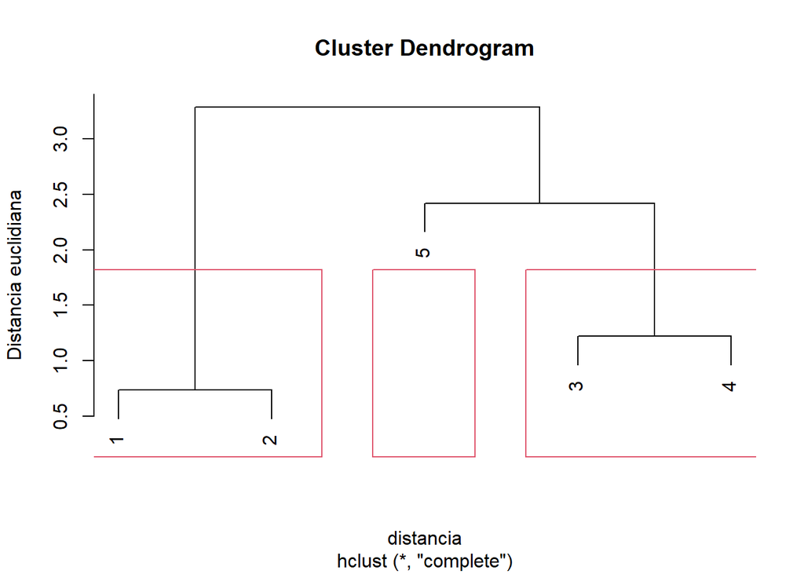

O perfil do primeiro grupo (candidatos 1 e 2) é recém formados com baixa experiência, o segundo grupo (candidato 5) é um funcionário freelancer e o último grupo (candidatos 3 e 4) são funcionários sêniors da empresa anterior.

3. Um técnico ajustou uma análise de cluster para separar jogadores de futebol, integrantes dos melhores clubes e seleções do mundo, em grupos. Essa avaliação levou em conta a idade dos jogadores, valor de mercado e salário de 2019, e algumas avaliações como reputação internacional e classificação geral e potencial (escores).
1. Qual jogador é o mais distinto de todos os outros?

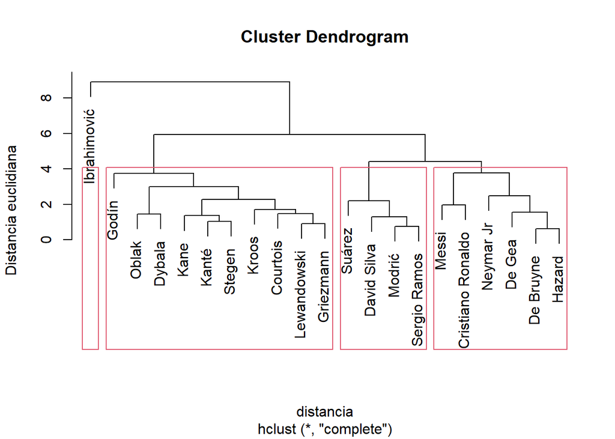

O jogador mais distinto de todos é Ibrahimović

2. Exclua o jogador mais distinto de todos. Considerando apenas 3 grupos, quais jogadores estão em cada grupo?

[output not shown]

4. Leia o texto acerca da Distância de Gower e segmentação com variáveis categorizadas. Reproduza-o no seu computador.